# Cohort selection

```python
%run initialise_pyark.py
```

```
POST https://bio-test-cva.gel.zone/cva/api/0/authentication?
Response time : 12 ms
```

```
pyark version 4.0.4
```

## Select cases based on a given segregation pattern

We store the counts of report events having each segregation pattern in the case in the field `countTieringSegregationPatterns`. We can then use the `filter` parameter to make any arithmetic filtering on those values. The main difficulty to use the `filter` parameter is that you need to know the underlying name of the field in the database you want to filter by; as opposed to other filters exposed in the REST API which are available in Swagger which happens to be the documentation of the REST API.

```python
cases_client.count(program="rare_disease", filter="countTieringSegregationPatterns.deNovo gt 0")
```

```
GET https://bio-test-cva.gel.zone/cva/api/0/cases?program=rare_disease&filter=countTieringSegregationPatterns.deNovo gt 0&count=True
Response time : 246 ms
```

```
8051
```

```python
cases_client.count(program="rare_disease", filter="countTieringSegregationPatterns.MitochondrialGenome gt 0")
```

```
GET https://bio-test-cva.gel.zone/cva/api/0/cases?program=rare_disease&filter=countTieringSegregationPatterns.MitochondrialGenome gt 0&count=True
Response time : 208 ms
```

```
4312
```

```python
cases_client.count(program="rare_disease", filter="countTieringSegregationPatterns.UniparentalIsodisomy gt 0")
```

```
GET https://bio-test-cva.gel.zone/cva/api/0/cases?program=rare_disease&filter=countTieringSegregationPatterns.UniparentalIsodisomy gt 0&count=True
Response time : 200 ms
```

```
5037
```

### Fetch the cases

Once we have the query to select our cohort we can fetch those cases. In order not to fetch all at once we need to use the parameter `limit` to determine the number of cases to be fetched in one single call. The `limit` maximum value is 200, any value greater than that will be considered as the maximum value. We can use the parameter `as_data_frame=True` to fetch the cases in a Pandas data frame or otherwise they will be returned in a native Python list of dictionaries.

For this example we will drill down into a smaller set of cases for the purpose of simplicity in the size of the data by adding some additional filtering.

```python
cases_client.count(program="rare_disease", filter="countTieringSegregationPatterns.deNovo gt 150")
```

```
GET https://bio-test-cva.gel.zone/cva/api/0/cases?program=rare_disease&filter=countTieringSegregationPatterns.deNovo gt 150&count=True
Response time : 231 ms
```

```
1232
```

```python
# fetch cases in batches of 100
denovo_cases_generator = cases_client.get_cases(program="rare_disease", hasPositiveDx=True, filter="countTieringSegregationPatterns.deNovo gt 150", limit=100, as_data_frame=True)
```

```python
# fetch the first batch
denovo_cases = next(denovo_cases_generator)
denovo_cases[["identifier", "version", "countTiered", "tieringVersion", "hasExitQuestionnaire", "hasPositiveDx"]].head()
```

```
GET https://bio-test-cva.gel.zone/cva/api/0/cases?program=rare_disease&hasPositiveDx=True&filter=countTieringSegregationPatterns.deNovo gt 150&limit=100&include=__all
Response time : 435 ms
```

| _index | identifier | version | countTiered | tieringVersion | hasExitQuestionnaire | hasPositiveDx |
| --- | --- | --- | --- | --- | --- | --- |
| 0 | 26401 | 1 | 19 | 1.0.0 | True | True |
| 1 | 22476 | 1 | 259 | 0.5.0 | True | True |
| 2 | 33166 | 1 | 255 | 1.0.0 | True | True |
| 3 | 11679 | 1 | 34 | 0.5.0 | True | True |
| 4 | 39732 | 1 | 29 | 1.0.14 | True | True |

```python
# get them all
for c in denovo_cases_generator:
    denovo_cases = denovo_cases.append(c)
```

```python
denovo_cases.shape
```

```
(29, 1945)
```

### Extract relevant information from cases

Now extract relevant information like case ids or count of tiered variants.

```python
denovo_cases[["identifier", "version", "countTiered", "tieringVersion", "hasExitQuestionnaire", "hasPositiveDx"]].head()
```

| _index | identifier | version | countTiered | tieringVersion | hasExitQuestionnaire | hasPositiveDx |
| --- | --- | --- | --- | --- | --- | --- |
| 0 | 26401 | 1 | 19 | 1.0.0 | True | True |
| 1 | 22476 | 1 | 259 | 0.5.0 | True | True |
| 2 | 33166 | 1 | 255 | 1.0.0 | True | True |
| 3 | 11679 | 1 | 34 | 0.5.0 | True | True |
| 4 | 39732 | 1 | 29 | 1.0.14 | True | True |

### Find cases where a given segregation pattern was tier 1 or 2

This information is not available in the case entity so we need to query the report events for each case in order to infer this information.

```python
# this makes one query per case
denovo_cases["countDeNovoTier12"] = denovo_cases.apply(lambda c: report_events_client.count(caseId=c.identifier, caseVersion=c.version, segregationPattern="deNovo", tiers=["TIER1", "TIER2"]), axis=1)
```

[output not shown]

```python
denovo_cases[denovo_cases["countDeNovoTier12"] > 0].shape
```

```
(19, 1946)
```

```python
denovo_cases[denovo_cases["countDeNovoTier12"] > 0][["identifier", "version", "countTiered", "countDeNovoTier12", "hasExitQuestionnaire", "hasPositiveDx"]].head()
```

| _index | identifier | version | countTiered | countDeNovoTier12 | hasExitQuestionnaire | hasPositiveDx |
| --- | --- | --- | --- | --- | --- | --- |
| 0 | 26401 | 1 | 19 | 2 | True | True |
| 2 | 33166 | 1 | 255 | 1 | True | True |
| 4 | 39732 | 1 | 29 | 2 | True | True |
| 6 | 29750 | 1 | 43 | 1 | True | True |
| 7 | 34553 | 1 | 13 | 3 | True | True |

## Select cases based on the number of variants of a certain type

We store the number of tiered variants by variant type as follows:

```
"countTieredByVariantType" : {
        "MNV" : 0,
        "DELETION" : 11,
        "INSERTION" : 6,
        "INDEL" : 17,
        "SNV" : 247
    },
```

We can fetch cases with an unusual number of variants of a certain type querying this data structure.

```python
cases_client.count(program="rare_disease", filter="countTieredByVariantType.INSERTION gt 50")
```

```
GET https://bio-test-cva.gel.zone/cva/api/0/cases?program=rare_disease&filter=countTieredByVariantType.INSERTION gt 50&count=True
Response time : 173 ms
```

```
16
```

```python
cases_client.count(program="rare_disease", filter="countTieredByVariantType.DELETION gt 50")
```

```
GET https://bio-test-cva.gel.zone/cva/api/0/cases?program=rare_disease&filter=countTieredByVariantType.DELETION gt 50&count=True
Response time : 188 ms
```

```
0
```

We can look at the distribution of these values in a given cohort previously downloaded.

```python
# NOTE: we are missing the count of panels as precomputed value in cases, we will add it soon...
denovo_cases["countPanels"] = denovo_cases["reportEventsAnalysisPanels"].apply(lambda p: len(p))
```

```python
denovo_cases[["countPanels", "countTieredByVariantType.DELETION", "countTieredByVariantType.INSERTION", "countTieredByVariantType.SNV"]]
```

| _index | countPanels | countTieredByVariantType.DELETION | countTieredByVariantType.INSERTION | countTieredByVariantType.SNV |
| --- | --- | --- | --- | --- |
| 0 | 6 | 0 | 1 | 17 |
| 1 | 7 | 3 | 15 | 241 |
| 2 | 4 | 10 | 7 | 235 |
| 3 | 8 | 2 | 2 | 30 |
| 4 | 3 | 1 | 1 | 25 |
| 5 | 6 | 1 | 1 | 33 |
| 6 | 10 | 5 | 1 | 35 |
| 7 | 5 | 2 | 1 | 8 |
| 8 | 4 | 9 | 18 | 234 |
| 9 | 5 | 2 | 2 | 20 |
| 10 | 8 | 0 | 0 | 31 |
| 11 | 10 | 4 | 2 | 15 |
| 12 | 5 | 2 | 0 | 27 |
| 13 | 5 | 1 | 4 | 20 |
| 14 | 5 | 1 | 1 | 14 |
| 15 | 6 | 1 | 4 | 32 |
| 16 | 4 | 7 | 14 | 194 |
| 17 | 6 | 2 | 2 | 57 |
| 18 | 3 | 3 | 0 | 23 |
| 19 | 13 | 0 | 1 | 20 |
| 20 | 7 | 1 | 3 | 12 |
| 21 | 3 | 0 | 0 | 18 |
| 22 | 7 | 1 | 0 | 19 |
| 23 | 6 | 1 | 0 | 41 |
| 24 | 7 | 1 | 0 | 27 |
| 25 | 4 | 11 | 13 | 248 |
| 26 | 5 | 1 | 1 | 36 |
| 27 | 2 | 1 | 0 | 38 |
| 28 | 3 | 0 | 1 | 14 |

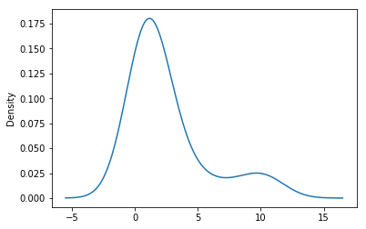

```python
denovo_cases["countTieredByVariantType.DELETION"].plot.kde()
```

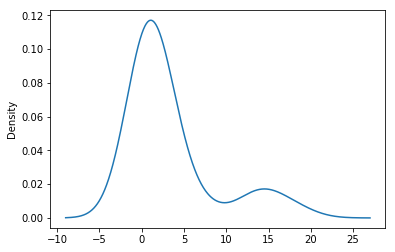

```python
denovo_cases["countTieredByVariantType.INSERTION"].plot.kde()
```

## Select cases based on the clinical data and case status

There are a number of fields related to the clinical data and the case status: `hasCanonicalTrio`, `hasFatherSequenced`, `hasMotherSequenced`, `probandYearOfBirth`, `probandSex`, `probandKaryotipicSex`, `probandEstimatedAgeAtAnalysis`, `probandAgeOfOnset`, `probandNumberDisorders`, `hasPositiveDx`, `hasNegativeDx`, `caseSolvedFamily`, `segregationQuestion`, `hasActionable`, `hasConfirmationDecision`, `hasPositiveConfirmationOutcome`, `countProbandPresentPhenotypes`, `hasClinicalReport`, `hasExitQuestionnaire`, `countParticipants`, `countSamples`

```python
cases_client.count(program="rare_disease", hasCanonicalTrio=True, hasPositiveDx=True)
```

```
GET https://bio-test-cva.gel.zone/cva/api/0/cases?program=rare_disease&hasCanonicalTrio=True&hasPositiveDx=True&count=True
Response time : 162 ms
```

```
711
```

```python
cases_client.count(program="rare_disease", hasCanonicalTrio=True, hasPositiveDx=False)
```

```
GET https://bio-test-cva.gel.zone/cva/api/0/cases?program=rare_disease&hasCanonicalTrio=True&hasPositiveDx=False&count=True
Response time : 178 ms
```

```
11343
```

```python
# get summary of cases to compare solved versus unsolved cases with a clinical trio
cases_client.get_summary(params_list=[
    {'program':'rare_disease', 'hasCanonicalTrio':True, 'hasPositiveDx':True},
    {'program':'rare_disease', 'hasCanonicalTrio':True, 'hasPositiveDx':False}],
                         as_data_frame=True)[['diagnosticRate', 'countCases']]
```

```
GET https://bio-test-cva.gel.zone/cva/api/0/cases/summary?program=rare_disease&hasCanonicalTrio=True&hasPositiveDx=True
Response time : 447 ms
GET https://bio-test-cva.gel.zone/cva/api/0/cases/summary?program=rare_disease&hasCanonicalTrio=True&hasPositiveDx=False
Response time : 898 ms
```

| program | hasCanonicalTrio | hasPositiveDx | diagnosticRate | countCases |
| --- | --- | --- | --- | --- |
| rare_disease | True | True | 1.000 | 711 |
|  |  | False | 0.000 | 11343 |

```python
# get summary of cases with different number of participants in the family
cases_client.get_summary(params_list=[
    {'program':'rare_disease', 'filter':'countParticipants eq 1'},
    {'program':'rare_disease', 'filter':'countParticipants eq 2'},
    {'program':'rare_disease', 'filter':'countParticipants eq 3'},
    {'program':'rare_disease', 'filter':'countParticipants eq 4'},
    {'program':'rare_disease', 'filter':'countParticipants eq 5'},
    {'program':'rare_disease', 'filter':'countParticipants eq 6'}
], as_data_frame=True)[['diagnosticRate', 'countCases']]
```

```
GET https://bio-test-cva.gel.zone/cva/api/0/cases/summary?program=rare_disease&filter=countParticipants eq 1
Response time : 838 ms
GET https://bio-test-cva.gel.zone/cva/api/0/cases/summary?program=rare_disease&filter=countParticipants eq 2
Response time : 590 ms
GET https://bio-test-cva.gel.zone/cva/api/0/cases/summary?program=rare_disease&filter=countParticipants eq 3
Response time : 892 ms
GET https://bio-test-cva.gel.zone/cva/api/0/cases/summary?program=rare_disease&filter=countParticipants eq 4
Response time : 402 ms
GET https://bio-test-cva.gel.zone/cva/api/0/cases/summary?program=rare_disease&filter=countParticipants eq 5
Response time : 348 ms
GET https://bio-test-cva.gel.zone/cva/api/0/cases/summary?program=rare_disease&filter=countParticipants eq 6
Response time : 353 ms
```

| program | filter | diagnosticRate | countCases |
| --- | --- | --- | --- |
| rare_disease | countParticipants eq 1 | 0.103 | 11898 |
|  | countParticipants eq 2 | 0.125 | 5425 |
|  | countParticipants eq 3 | 0.185 | 11708 |
|  | countParticipants eq 4 | 0.231 | 1195 |
|  | countParticipants eq 5 | 0.431 | 249 |
|  | countParticipants eq 6 | 0.500 | 47 |

```python
# get summary of cases with different proband age ranges
cases_client.get_summary(params_list=[
    {'program':'rare_disease', 'filter':'probandEstimatedAgeAtAnalysis lt 2'},
    {'program':'rare_disease',
     'filter':'probandEstimatedAgeAtAnalysis lt 10 and probandEstimatedAgeAtAnalysis ge 2'},
    {'program':'rare_disease',
     'filter':'probandEstimatedAgeAtAnalysis lt 18 and probandEstimatedAgeAtAnalysis ge 10'},
    {'program':'rare_disease', 'filter':'probandEstimatedAgeAtAnalysis ge 18'}
], as_data_frame=True)[['diagnosticRate', 'countCases']]
```

```
GET https://bio-test-cva.gel.zone/cva/api/0/cases/summary?program=rare_disease&filter=probandEstimatedAgeAtAnalysis lt 2
Response time : 441 ms
GET https://bio-test-cva.gel.zone/cva/api/0/cases/summary?program=rare_disease&filter=probandEstimatedAgeAtAnalysis lt 10 and probandEstimatedAgeAtAnalysis ge 2
Response time : 797 ms
GET https://bio-test-cva.gel.zone/cva/api/0/cases/summary?program=rare_disease&filter=probandEstimatedAgeAtAnalysis lt 18 and probandEstimatedAgeAtAnalysis ge 10
Response time : 681 ms
GET https://bio-test-cva.gel.zone/cva/api/0/cases/summary?program=rare_disease&filter=probandEstimatedAgeAtAnalysis ge 18
Response time : 1226 ms
```

| program | filter | diagnosticRate | countCases |
| --- | --- | --- | --- |
| rare_disease | probandEstimatedAgeAtAnalysis lt 2 | 0.302 | 176 |
|  | probandEstimatedAgeAtAnalysis lt 10 and probandEstimatedAgeAtAnalysis ge 2 | 0.198 | 7350 |
|  | probandEstimatedAgeAtAnalysis lt 18 and probandEstimatedAgeAtAnalysis ge 10 | 0.168 | 4742 |
|  | probandEstimatedAgeAtAnalysis ge 18 | 0.127 | 18000 |

```python
# get summary of cases with different count of phenotypes
cases_client.get_summary(params_list=[
    {'program':'rare_disease', 'filter':'countProbandPresentPhenotypes eq 1'},
    {'program':'rare_disease', 'filter':'countProbandPresentPhenotypes eq 2'},
    {'program':'rare_disease', 'filter':'countProbandPresentPhenotypes eq 3'},
    {'program':'rare_disease', 'filter':'countProbandPresentPhenotypes eq 4'},
    {'program':'rare_disease', 'filter':'countProbandPresentPhenotypes eq 5'},
    {'program':'rare_disease', 'filter':'countProbandPresentPhenotypes eq 6'}
], as_data_frame=True)[['diagnosticRate', 'countCases']]
```

```
GET https://bio-test-cva.gel.zone/cva/api/0/cases/summary?program=rare_disease&filter=countProbandPresentPhenotypes eq 1
Response time : 466 ms
GET https://bio-test-cva.gel.zone/cva/api/0/cases/summary?program=rare_disease&filter=countProbandPresentPhenotypes eq 2
Response time : 494 ms
GET https://bio-test-cva.gel.zone/cva/api/0/cases/summary?program=rare_disease&filter=countProbandPresentPhenotypes eq 3
Response time : 497 ms
GET https://bio-test-cva.gel.zone/cva/api/0/cases/summary?program=rare_disease&filter=countProbandPresentPhenotypes eq 4
Response time : 478 ms
GET https://bio-test-cva.gel.zone/cva/api/0/cases/summary?program=rare_disease&filter=countProbandPresentPhenotypes eq 5
Response time : 461 ms
GET https://bio-test-cva.gel.zone/cva/api/0/cases/summary?program=rare_disease&filter=countProbandPresentPhenotypes eq 6
Response time : 469 ms
```

| program | filter | diagnosticRate | countCases |
| --- | --- | --- | --- |
| rare_disease | countProbandPresentPhenotypes eq 1 | 0.103 | 2901 |
|  | countProbandPresentPhenotypes eq 2 | 0.113 | 3567 |
|  | countProbandPresentPhenotypes eq 3 | 0.117 | 3337 |
|  | countProbandPresentPhenotypes eq 4 | 0.136 | 2987 |
|  | countProbandPresentPhenotypes eq 5 | 0.134 | 2802 |
|  | countProbandPresentPhenotypes eq 6 | 0.141 | 2458 |

```python
# get summary of cases with different values of information content
cases_client.get_summary(params_list=[
    {'program':'rare_disease', 'filter':'probandPresentPhenotypesInformationContent le 1'},
    {'program':'rare_disease',
     'filter':'probandPresentPhenotypesInformationContent le 2 and probandPresentPhenotypesInformationContent gt 1'},
    {'program':'rare_disease',
     'filter':'probandPresentPhenotypesInformationContent le 3 and probandPresentPhenotypesInformationContent gt 2'},
    {'program':'rare_disease',
     'filter':'probandPresentPhenotypesInformationContent le 4 and probandPresentPhenotypesInformationContent gt 3'},
    {'program':'rare_disease',
     'filter':'probandPresentPhenotypesInformationContent le 5 and probandPresentPhenotypesInformationContent gt 4'},
    {'program':'rare_disease',
     'filter':'probandPresentPhenotypesInformationContent le 6 and probandPresentPhenotypesInformationContent gt 5'},
    {'program':'rare_disease',
     'filter':'probandPresentPhenotypesInformationContent le 7 and probandPresentPhenotypesInformationContent gt 6'},
    {'program':'rare_disease',
     'filter':'probandPresentPhenotypesInformationContent gt 7'}
], as_data_frame=True)[['diagnosticRate', 'countCases']]
```

```
GET https://bio-test-cva.gel.zone/cva/api/0/cases/summary?program=rare_disease&filter=probandPresentPhenotypesInformationContent le 1
Response time : 405 ms
GET https://bio-test-cva.gel.zone/cva/api/0/cases/summary?program=rare_disease&filter=probandPresentPhenotypesInformationContent le 2 and probandPresentPhenotypesInformationContent gt 1
Response time : 402 ms
GET https://bio-test-cva.gel.zone/cva/api/0/cases/summary?program=rare_disease&filter=probandPresentPhenotypesInformationContent le 3 and probandPresentPhenotypesInformationContent gt 2
Response time : 395 ms
GET https://bio-test-cva.gel.zone/cva/api/0/cases/summary?program=rare_disease&filter=probandPresentPhenotypesInformationContent le 4 and probandPresentPhenotypesInformationContent gt 3
Response time : 611 ms
GET https://bio-test-cva.gel.zone/cva/api/0/cases/summary?program=rare_disease&filter=probandPresentPhenotypesInformationContent le 5 and probandPresentPhenotypesInformationContent gt 4
Response time : 839 ms
GET https://bio-test-cva.gel.zone/cva/api/0/cases/summary?program=rare_disease&filter=probandPresentPhenotypesInformationContent le 6 and probandPresentPhenotypesInformationContent gt 5
Response time : 787 ms
GET https://bio-test-cva.gel.zone/cva/api/0/cases/summary?program=rare_disease&filter=probandPresentPhenotypesInformationContent le 7 and probandPresentPhenotypesInformationContent gt 6
Response time : 680 ms
GET https://bio-test-cva.gel.zone/cva/api/0/cases/summary?program=rare_disease&filter=probandPresentPhenotypesInformationContent gt 7
Response time : 667 ms
```

| program | filter | diagnosticRate | countCases |
| --- | --- | --- | --- |
| rare_disease | probandPresentPhenotypesInformationContent le 1 | 0.500 | 4 |
|  | probandPresentPhenotypesInformationContent le 4 and probandPresentPhenotypesInformationContent gt 3 | 0.281 | 3622 |
|  | probandPresentPhenotypesInformationContent le 5 and probandPresentPhenotypesInformationContent gt 4 | 0.201 | 8017 |
|  | probandPresentPhenotypesInformationContent le 6 and probandPresentPhenotypesInformationContent gt 5 | 0.152 | 7594 |
|  | probandPresentPhenotypesInformationContent le 7 and probandPresentPhenotypesInformationContent gt 6 | 0.116 | 5344 |
|  | probandPresentPhenotypesInformationContent gt 7 | 0.095 | 5936 |

## Select cases by their genomic data

```python
## Select cases with a positive Dx by diagnostic gene
cases_client.count(
    hasPositiveDx=True,
    filter="classifiedGenes.pathogenic_variant eq 'ENSG00000008710' or classifiedGenes.likely_pathogenic_variant eq 'ENSG00000008710'")
```

```
GET https://bio-test-cva.gel.zone/cva/api/0/cases?hasPositiveDx=True&filter=classifiedGenes.pathogenic_variant eq 'ENSG00000008710' or classifiedGenes.likely_pathogenic_variant eq 'ENSG00000008710'&count=True
Response time : 266 ms
```

```
91
```

```python
## Select cases with a positive Dx from a tier 3
cases_client.count(
    hasPositiveDx=True,
    filter="countTieredAndClassified.TIER3.pathogenic_variant gt 0 and " +
        "countTieredAndClassified.TIER1.pathogenic_variant eq 0 and " +
        "countTieredAndClassified.TIER1.likely_pathogenic_variant eq 0 and " +
        "countTieredAndClassified.TIER2.pathogenic_variant eq 0 and " +
        "countTieredAndClassified.TIER2.likely_pathogenic_variant eq 0")
```

```
GET https://bio-test-cva.gel.zone/cva/api/0/cases?hasPositiveDx=True&filter=countTieredAndClassified.TIER3.pathogenic_variant gt 0 and countTieredAndClassified.TIER1.pathogenic_variant eq 0 and countTieredAndClassified.TIER1.likely_pathogenic_variant eq 0 and countTieredAndClassified.TIER2.pathogeni…
Response time : 249 ms
```

```
57
```

```python
cases_client.count(
    hasPositiveDx=True,
    filter="countTieredAndClassified.TIER3.likely_pathogenic_variant gt 0 and " +
        "countTieredAndClassified.TIER1.pathogenic_variant eq 0 and " +
        "countTieredAndClassified.TIER1.likely_pathogenic_variant eq 0 and " +
        "countTieredAndClassified.TIER2.pathogenic_variant eq 0 and " +
        "countTieredAndClassified.TIER2.likely_pathogenic_variant eq 0")
```

```
GET https://bio-test-cva.gel.zone/cva/api/0/cases?hasPositiveDx=True&filter=countTieredAndClassified.TIER3.likely_pathogenic_variant gt 0 and countTieredAndClassified.TIER1.pathogenic_variant eq 0 and countTieredAndClassified.TIER1.likely_pathogenic_variant eq 0 and countTieredAndClassified.TIER2.pa…
Response time : 244 ms
```

```
69
```